# Snabb Reference Manual

# Test Apps

## Match (apps.test.match)

The `Match` app compares packets received on its input port `rx` with those received on the reference input port `comparator`, and reports mismatches as well as packets from `comparator` that were not matched.

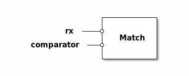

Match

— Method **Match:errors**

Returns the recorded errors as an array of strings.

### Configuration

The `Match` app accepts a table as its configuration argument. The following keys are defined:

— Key **fuzzy**

*Optional.* If this key is `true` packets from `rx` that do not match the next packet from `comparator` are ignored. The default is `false`.

— Key **modest**

*Optional.* If this key is `true` unmatched packets from `comparator` are ignored if at least one packet from ´rx´ was successfully matched. The default is `false`.

## Synth (apps.test.synth)

The `Synth` app generates synthetic packets with Ethernet headers and alternating payload sizes. On each breath it fills each attached output link with new packets.

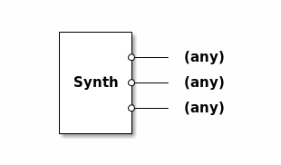

Synth

### Configuration

The `Synth` app accepts a table as its configuration argument. The following keys are defined:

— Key **src**

— Key **dst**

Source and destination MAC addresses in human readable from. The default is `"00:00:00:00:00:00"`.

— Key **sizes**

An array of numbers designating the packet payload sizes. The default is `{64}`.

# SnabbWall Apps

## L7Spy (apps.wall.l7spy)

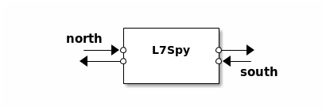

L7Spy

The `L7Spy` app is a Snabb app that scans packets passing through it using an instance of the `Scanner` class. The scanner instance may be shared among several `L7Spy` instances or with a `L7Fw` app for filtering.

— Method **L7Spy:new** *config*

Construct a new `L7Spy` app instance based on a given configuration table. The table may contain the following key:

- `scanner` (optional): Either a string identifying the kind of scanner to construct (currently only `"ndpi"` is accepted) or an existing scanner instance.

## Filter (apps.wall.filter)

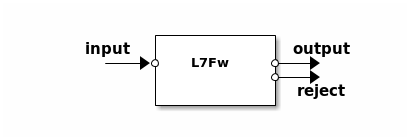

L7Fw

The `L7Fw` app implements a stateful firewall by querying the scanner state collected by a `L7Spy` app. It then filters packets based on a given set of rules.

— Method **L7Fw:new** *config*

Construct a new `L7Fw` app instance based on a given configuration table. The table may contain the following keys:

- `scanner`: A `Scanner` instance shared with an `L7Spy` instance. The metadata in this scanner is used for packet filtering.
- `rules`: A table mapping protocol names (as strings) to firewall actions. The accepted actions are `"accept"`, `"reject"`, `"drop"`, or a pfmatch expression. The pfmatch expression may use the variable `flow_count` (as an arithmetic expression) to refer to the number of packets in a given protocol flow, and may call the `accept`, `reject`, or `drop` methods.
- `local_ipv4` (optional): An IPv4 address that identifies the host running the firewall. This is used as the source address in ICMPv4 or TCP reject responses.
- `local_ipv6` (optional): An IPv6 address that identifies the host running the firewall. This is used as the source address in ICMPv6 or TCP reject responses.
- `local_macaddr` (optional): A MAC address that identifies the host running the firewall. This is used for the source address in ethernet frames for reject responses.
- `logging` (optional): A log level parameter that can be set to “on” or “off”. When set to “on”, it will report dropped/rejected packets to the system log.

## Scanner (apps.wall.scanner)

`Scanner` objects are responsible for:

- Identifying traffic flows.
- Analyzing the contents of packet to determine which application they belong to.
- Keeping enough state to be able to enumerate the identified traffic flows, and identify the application they belong to.

The class is not meant to be instantiated directly, but to be used as the basis for concrete implementations (e.g. `NdpiScanner`). It provides one function that subclasses can use:

- Method **Scanner:extract_packet_info** *packet*

Extracts fields from the headers of an IPv4 or IPv6 *packet*. The returned values are:

1. A *key* object (more on this below) which uniquely identifies a traffic flow.
2. The *offset* to the packet payload content.
3. The *source_address* of the packet, as an array of bytes.
4. The *source_port*, for UDP and TCP packets.
5. The *destination_address* of the packet, as an array of bytes.
6. The *destination_port*, for UDP and TCP packets.

Key objects contain some of the returned information in a compact FFI representation, and can be used as an aid to uniquely identify a flow of packets. The provide the following attributes:

- `:eth_type()`: Method which returns the type of the Ethernet frame payload, either `ETH_TYPE_IPv4` or `ETH_TYPE_IPv6`.
- `:hash()`: Method which returns an integer calculated by hashing all the other values in the key object.
- `.vlan_id`: VLAN identifier. Zero for no VLAN tags.
- `.ip_proto`: The IP protocol.
- `.lo_addr` and `.hi_addr`: IP addresses (either v4 or v6).
- `.lo_port` and `.hi_port`: For TCP and UDP, the ports as big-endian (network) integers.

This method can be very useful to implement scanners using backends which do not implement their own flow classification.

### Subclassing

All the `Scanner` implementations conform to the `Scanner` base API.

— Method **Scanner:scan_packet** *packet*, *time*

Scans a *packet*.

The *time* parameter is used to know at which time (in seconds from the Epoch) *packet* has been received for processing. A suitable value can be obtained using `engine.now()`.

— Method **Scanner:get_flow** *packet*

Obtains the traffic flow for a given *packet*. If the packet is determined to not match any of the detected flows, `nil` is returned. The returned flow object has at least the following fields:

- `protocol`: The L7 protocol for the flow. A user-visible string can be obtained by passing this value to `Scanner:protocol_name()`.
- `packets`: Number of packets scanned which belong to the traffic flow.
- `last_seen`: Last time (in seconds from the Epoch) at which a packet belonging to the flow has been scanned.

— Method **Scanner:flows**

Returns an iterator over all the traffic flows detected by the scanner. The returned value is suitable to be used in a `for`-loop:

```lua
for flow in my_scanner:flows() do
   -- Do something with "flow".
end
```

— Method **Scanner:protocol_name** *protocol*

Given a *protocol* identifier, returns a user-friendly name as a string. Typically the *protocol* is obtained flow objects returned by `Scanner:get_flow()`.

### NdpiScanner (apps.wall.scanner.ndpi)

`NdpiScanner` uses the [nDPI](http://www.ntop.org/products/deep-packet-inspection/ndpi/) library (via the ljndpi FFI binding) to scan packets and determine L7 traffic flows. The nDPI library (`libndpi.so`) must be available in the host system. Versions 1.7 and 1.8 are supported.

— Method **NdpiScanner:new** *ticks_per_second*

Creates a new scanner, with a *ticks_per_second* resolution.

## Utilities

The `apps.wall.util` module contains miscellaneous utilities.

— Function **util.ipv4_addr_cmp** *a*, *b*

Compares two IPv4 addresses *a* and *b*. The returned value follows the same convention as for `C.memcmp()`: zero if both addresses are equal, or an integer value with the same sign as the sign of the difference between the first pair of bytes that differ in *a* and *b*.

— Function **util.ipv6_addr_cmp** *a*, *b*

Compares two IPv6 addresses *a* and *b*. The returned value follows the same convention as for `C.memcmp()`: zero if both addresses are equal, or an integer value with the same sign as the sign of the difference between the first pair of bytes that differ in *a* and *b*.

### SouthAndNorth (apps.wall.util)

The `SouthAndNorth` application is not to mean to be used directly, but rather as a building block for more complex applications which need two duplex ports (`south` and `north`) which forward packets between them, optionally doing some intermediate processing.

Packets arriving to the `north` port are passed to the `:on_southbound_packet()` method —which can be overriden in a subclass—, and forwarded to the `south` port. Conversely, packets arriving to the `south` port are passed to `:on_northbound_packet()` method, and finally forwarded to the `north` port.

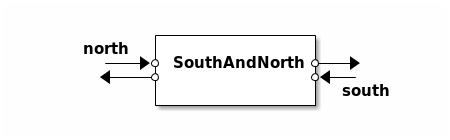

SouthAndNorth

The value returnbyed `:on_southbound_packet()` and `:on_northbound_packet()` determines what will be done to the packet being processed:

- Returning `false` discards the packet: the packet will *not* be forwarded, and `packet.free()` will be called on it.
- Returning a different packet replaces the packet: the packet originally being processed is discarded, `packet.free()` called on it, and the returned packet is forwarded.
- Returning the same packet being handled will forward it. Retuning `nil` achieves the same effect.

#### Example

The following snippet defines an application derived from `SouthAndNorth` which silently discards packets bigger than a certain size, and keeps a count of how many packets have been discarded and forwarded:

```lua
-- Setting SouthAndNorth as metatable "inherits" from it.
DiscardBigPackets = setmetatable({},
   require("apps.wall.util").SouthAndNorth)

function DiscardBigPackets:new (max_length)
   return setmetatable({
      max_packet_length = max_length,
      discarded_packets = 0,
      forwarded_packets = 0,
   }, self)
end

function DiscardBigPackets:on_northbound_packet (pkt)
   if pkt.length > self.max_packet_length then
      self.discarded_packets = self.discarded_packets + 1
      return false
   end
   self.forwarded_packets = self.forwarded_packets + 1
end

-- Apply the same logic for packets in the other direction.
DiscardBigPackets.on_southbound_packet =
   DiscardBigPackets.on_northbound_packet
```

# Libraries

### IP checksum (lib.checksum)

The checksum module provides an optimized ones-complement checksum routine.

— Function **ipsum** *pointer* *length* *initial*

Return the ones-complement checksum for the given region of memory.

*pointer* is a pointer to an array of data to be checksummed. *initial* is an unsigned 16-bit number in host byte order which is used as the starting value of the accumulator. The result is the IP checksum over the data in host byte order.

The *initial* argument can be used to verify a checksum or to calculate the checksum in an incremental manner over chunks of memory. The synopsis to check whether the checksum over a block of data is equal to a given value is the following

```
if ipsum(pointer, length, value) == 0 then
  -- checksum correct
else
  -- checksum incorrect
end
```

To chain the calculation of checksums over multiple blocks of data together to obtain the overall checksum, one needs to pass the one’s complement of the checksum of one block as initial value to the call of ipsum() for the following block, e.g.

```
local sum1 = ipsum(data1, length1, 0)
local total_sum = ipsum(data2, length2, bit.bnot(sum1))
```

This function takes advantage of SIMD hardware when available.

### Ctable (lib.ctable)

A *ctable* is a hash table whose keys and values are instances of FFI data types. In Lua parlance, an FFI value is a “cdata” value, hence the name “ctable”.

A ctable is parameterized for the specific types for its keys and values. This allows for the table to be stored in an efficient manner. Adding an entry to a ctable will copy the value into the table. Logically, the table “owns” the value. Lookup can either return a pointer to the value in the table, or copy the value into a user-supplied buffer, depending on what is most convenient for the user.

To create a ctable, first create a parameters table specifying the key and value types, along with any other options. Then call `ctable.new` on those parameters. For example:

```lua
local ctable = require('lib.ctable')
local ffi = require('ffi')
local params = {
   key_type = ffi.typeof('uint32_t'),
   value_type = ffi.typeof('int32_t[6]'),
   max_occupancy_rate = 0.4,
   initial_size = math.ceil(occupancy / 0.4)
}
local ctab = ctable.new(params)
```

— Function **ctable.new** *parameters*

Create a new ctable. *parameters* is a table of key/value pairs. The following keys are required:

- `key_type`: An FFI type (LuaJIT “ctype”) for keys in this table.
- `value_type`: An FFI type (LuaJT “ctype”) for values in this table.

Optional entries that may be present in the *parameters* table include:

- `hash_seed`: A hash seed, as a 16-byte array. The hash value of a key is a function of the key and also of the hash seed. Using a hash function with a seed prevents some kinds of denial-of-service attacks against network functions that use ctables. The seed defaults to a fresh random byte string. The seed also changes whenever a table is resized.
- `initial_size`: The initial size of the hash table, including free space. Defaults to 8 slots.
- `max_occupancy_rate`: The maximum ratio of `occupancy/size`, where `occupancy` denotes the number of entries in the table, and `size` is the total table size including free entries. Trying to add an entry to a “full” table will cause the table to grow in size by a factor of
2. Defaults to 0.9, for a 90% maximum occupancy ratio.
- `min_occupancy_rate`: Minimum ratio of `occupancy/size`. Removing an entry from an “empty” table will shrink the table.

— Function **ctable.load** *stream* *parameters*

Load a ctable that was previously saved out to a binary format. *parameters* are as for `ctable.new`. *stream* should be an object that has a **:read_ptr**(*ctype*) method, which returns a pointer to an embedded instances of *ctype* in the stream, advancing the stream over the object; and **:read_array**(*ctype*, *count*) which is the same but reading *count* instances of *ctype* instead of just one.

#### Methods

Users interact with a ctable through methods. In these method descriptions, the object on the left-hand-side of the method invocation should be a ctable.

— Method **:resize** *size*

Resize the ctable to have *size* total entries, including empty space.

— Method **:add** *key*, *value*, *updates_allowed*

Add an entry to the ctable, returning the index of the added entry. *key* and *value* are FFI values for the key and the value, of course.

*updates_allowed* is an optional parameter. If not present or false, then the `:insert` method will raise an error if the *key* is already present in the table. If *updates_allowed* is the string `"required"`, then an error will be raised if *key* is *not* already in the table. Any other true value allows updates but does not require them. An update will replace the existing entry in the table.

Returns the index of the inserted entry.

— Method **:update** *key*, *value*

Update the entry in a ctable with the key *key* to have the new value *value*. Throw an error if *key* is not present in the table.

— Method **:lookup_ptr** *key*

Look up *key* in the table, and if found return a pointer to the entry. Return nil if the value is not found.

An entry pointer has three fields: the `hash` value, which must not be modified; the `key` itself; and the `value`. Access them as usual in Lua:

```lua
local ptr = ctab:lookup(key)
if ptr then print(ptr.value) end
```

Note that pointers are only valid until the next modification of a table.

— Method **:lookup_and_copy** *key*, *entry*

Look up *key* in the table, and if found, copy that entry into *entry* and return true. Otherwise return false.

— Method **:remove_ptr** *entry*

Remove an entry from a ctable. *entry* should be a pointer that points into the table. Note that pointers are only valid until the next modification of a table.

— Method **:remove** *key*, *missing_allowed*

Remove an entry from a ctable, keyed by *key*.

Return true if we actually do find a value and remove it. Otherwise if no entry is found in the table and *missing_allowed* is true, then return false. Otherwise raise an error.

— Method **:save** *stream*

Save a ctable to a byte sink. *stream* should be an object that has a **:write_ptr**(*ctype*) method, which writes an instance of a struct type out to a stream, and **:write_array**(*ctype*, *count*) which is the same but writing *count* instances of *ctype* instead of just one.

— Method **:selfcheck**

Run an expensive internal diagnostic to verify that the table’s internal invariants are fulfilled.

— Method **:dump**

Print out the entries in a table. Can be expensive if the table is large.

— Method **:iterate**

Return an iterator for use by `for in`. For example:

```lua
for entry in ctab:iterate() do
   print(entry.key, entry.value)
end
```

#### Streaming interface

As an implementation detail, the table is stored as an open-addressed robin-hood hash table with linear probing. Ctables use the high-quality SipHash hash function to allow for good distribution of hash values. To find a value associated with a key, a ctable will first hash the key, map that hash value to an index into the table by scaling the hash to the table size, and then scan forward in the table until we find an entry whose hash value is greater than or equal to the hash in question. Each entry stores its hash value, and empty entries have a hash of `0xFFFFFFFF`. If the entry’s hash matches and the entry’s key is equal to the one we are looking for, then we have our match. If the entry’s hash is greater than our hash, then we have a failure. Hash collisions are possible as well of course; in that case we continue scanning forward.

The distance travelled while scanning for the matching hash is known as the *displacement*. The table measures its maximum displacement, for a number of purposes, but you might be interested to know that a maximum displacement for a table with 2 million entries and a 40% load factor is around 8 or 9. Smaller tables will have smaller maximum displacements.

The ctable has two lookup interfaces. The first one is the `lookup` methods described above. The other interface will fetch all entries within the maximum displacement into a buffer, then do a branchless binary search over that buffer. This second streaming lookup can also fetch entries for multiple keys in one go. This can amortize the cost of a round-trip to RAM, in the case where you expect to miss cache for every lookup.

To perform a streaming lookup, first prepare a `LookupStreamer` for the batch size that you need. You will have to experiment to find the batch size that works best for your table’s entry sizes; for reference, for 32-byte entries a 32-wide lookup seems to be optimum.

```lua
-- Stream in 32 lookups at once.
local stride = 32
local streamer = ctab:make_lookup_streamer(stride)
```

Wiring up streaming lookup in a packet-processing network is a bit of a chore currently, as you have to maintain separate queues of lookup keys and packets, assuming that each lookup maps to a packet. Let’s make a little helper:

```lua
local lookups = {
   queue = ffi.new("struct packet * [?]", stride),
   queue_len = 0,
   streamer = streamer
}

local function flush(lookups)
   if lookups.queue_len > 0 then
      -- Here is the magic!
      lookups.streamer:stream()
      for i = 0, lookups.queue_len - 1 do
         local pkt = lookups.queue[i]
         if lookups.streamer:is_found(i)
            local val = lookups.streamer.entries[i].value
            --- Do something cool here!
         end
      end
      lookups.queue_len = 0
   end
end

local function enqueue(lookups, pkt, key)
   local n = lookups.queue_len
   lookups.streamer.entries[n].key = key
   lookups.queue[n] = pkt
   n = n + 1
   if n == stride then
      flush(lookups)
   else
      lookups.queue_len = n
   end
end
```

Then as you see packets, you enqueue them via `enqueue`, extracting out the key from the packet in some way and passing that value as the argument. When `enqueue` detects that the queue is full, it will flush it, performing the lookups in parallel and processing the results.

### PMU (lib.pmu)

The CPU’s PMU (Performance Monitoring Unit) collects information about specific *performance events* such as cache misses, branch mispredictions, and utilization of internal CPU resources like execution units. This module provides an API for counting events with the PMU.

Hundreds of low-level counters are available. The exact list depends on CPU model. See pmu_cpu.lua for our definitions.

#### High-level interface

— Function **is_available**

If the PMU hardware is available then return true. Otherwise return two values: false and a string briefly explaining why. (Cooperation from the Linux kernel is required to acess the PMU.)

— Function **profile** *function* *[event_list]* *[aux]*

Call *function*, return the result, and print a human-readable report of the performance events that were counted during execution.

— Function **measure** *function* *[event_list]*

Call *function* and return two values: the result and a table of performance event counter tallies.

#### Low-level interface

— Function **setup** *event_list*

Setup the hardware performance counters to track a given list of events (in addition to the built-in fixed-function counters).

Each event is a Lua string pattern. This could be a full event name:

```
mem_load_uops_retired.l1_hit
```

or a more general pattern that matches several counters:

```
mem_load.*l._hit
```

Return the number of overflowed counters that could not be tracked due to hardware constraints. These will be the last counters in the list.

Example:

```
setup({"uops_issued.any",
       "uops_retired.all",
       "br_inst_retired.conditional",
       "br_misp_retired.all_branches"}) => 0
```

— Function **new_counter_set**

Return a `counter_set` object that can be used for accumulating events. The counter_set will be valid only until the next call to setup().

— Function **switch_to** *counter_set*

Switch to a new set of counters to accumulate events in. Has the side-effect of committing the current accumulators to the previous record.

If *counter_set* is nil then do not accumulate events.

— Function **to_table** *counter_set*

Return a table containing the values accumulated in *counter_set*.

Example:

```
to_table(cs) =>
  {
   -- Fixed-function counters
   instructions                 = 133973703,
   cycles                       = 663011188,
   ref-cycles                   = 664029720,
   -- General purpose counters selected with setup()
   uops_issued.any              = 106860997,
   uops_retired.all             = 106844204,
   br_inst_retired.conditional  =  26702830,
   br_misp_retired.all_branches =       419
  }
```

— Function **report** *counter_set* *[aux]*

Print a textual report on the values accumulated in a counter set. Optionally include auxiliary application-level counters. The ratio of each event to each auxiliary counter is also reported.

Example:

```
report(my_counter_set, {packet = 26700000, breath = 208593})
```

prints output approximately like:

```
EVENT                                   TOTAL     /packet     /breath
instructions                      133,973,703       5.000     642.000
cycles                            663,011,188      24.000    3178.000
ref-cycles                        664,029,720      24.000    3183.000
uops_issued.any                   106,860,997       4.000     512.000
uops_retired.all                  106,844,204       4.000     512.000
br_inst_retired.conditional        26,702,830       1.000     128.000
br_misp_retired.all_branches              419       0.000       0.000
packet                             26,700,000       1.000     128.000
breath                                208,593       0.008       1.000
```

## Hardware

### PCI (lib.hardware.pci)

The `lib.hardware.pci` module provides functions that abstract common operations on PCI devices on Linux. In order to drive a PCI device using [Direct memory access (DMA)](https://en.wikipedia.org/wiki/Direct_memory_access) one must:

1. Unbind the PCI device using `pci.unbind_device_from_linux`.
2. Enable PCI bus mastering for device using `pci.set_bus_master` in order to enable DMA.
3. Memory map PCI device configuration space using `pci.map_pci_memory`.
4. Control the PCI device by manipulating the memory referenced by the pointer returned by `pci.map_pci_memory`.
5. Disable PCI bus master for device using `pci.set_bus_master`.
6. Unmap PCI device configuration space using `pci.close_pci_resource`.

The correct ordering of these steps is absolutely critical.

— Variable **pci.devices**

An array of supported hardware devices. Must be populated by calling `pci.scan_devices`. Each entry is a table as returned by `pci.device_info`.

— Function **pci.canonical** *pciaddress*

Returns the canonical representation of a PCI address. The canonical representation is preferred internally in Snabb and for presenting to users. It shortens addresses with leading zeros like this: `0000:01:00.0` becomes `01:00.0`.

— Function **pci.qualified** *pciaddress*

Returns the fully qualified representation of a PCI address. Fully qualified addresses have the form `0000:01:00.0` and so this function undoes any abbreviation in the canonical representation.

— Function **pci.scan_devices**

Scans for available PCI devices and populates the `pci.devices` table.

— Function **pci.device_info** *pciaddress*

Returns a table containing information about the PCI device by *pciaddress*. The table has the following keys:

- `pciaddress`—String denoting the PCI address of the device. E.g. `"0000:83:00.1"`.
- `vendor`—Identification string e.g. `"0x8086"` for Intel.
- `device`—Identification string e.g. `"0x10fb"` for 82599 chip.
- `interface`—Name of Linux interface using this device e.g. `"eth0"`.
- `status`—String denoting the Linux operational status, or `nil` if not known.
- `driver`—String denoting the Lua module that supports this hardware e.g. `"apps.intel.intel10g"`.
- `usable`—String denoting if the device was suitable to use when scanned. One of `"yes"` or `"no"`.

— Function **pci.which_driver** *vendor*, *model*

Returns the module name for a suitable device driver (if available) for a device of *model* from *vendor*.

— Function **pci.unbind_device_from_linux** *pciaddress*

Forces Linux to unbind the device identified by *pciaddress* from any kernel drivers.

— Function **pci.set_bus_master** *pciaddress*, *enable*

Enables or disables PCI bus mastering for device identified by *pciaddress* depending on whether *enable* is a true or a false value. PCI bus mastering must be enabled in order to perform DMA on the PCI device.

— Function **pci.map_pci_memory_unlocked** *pciaddress*, *n* — Function **pci.map_pci_memory_locked** *pciaddress*, *n*

Memory maps configuration space *n* of PCI device identified by *pciaddress*. Returns a pointer to the memory mapped region and a file descriptor of the opened sysfs resource file. PCI bus mastering must be enabled on the device identified by *pciaddress* before calling this function. The 2 variants indicate if the underlying memory mapped file should be exclusively `flocked` or not.

— Function **pci.close_pci_resource** *file_descriptor*, *pointer*

Closes memory mapped *file_descriptor* of sysfs resource file and unmaps it from *pointer* as returned by `pci.map_pci_memory`.

### Register (lib.hardware.register)

The `lib.hardware.register` module provides an abstraction for hardware device registers. This abstraction can be used to declaratively specify and conveniently manipulate structured memory regions via DMA. The functions `register.define` and `register.define_array` construct `Register` objects based on a *register description* string. The resulting `Register` objects can be used to manipulate the defined registers using the methods `Register:read`, `Register:write`, `Register:set`, `Register:clr`, `Register:wait` and `Register:reset` (exact set depends on the *register mode*).

A register description is a string with one `Register` object definition per line. A `Register` object definition must be expressed using the following grammar:

```
Register   ::= Name Offset Indexing Mode Longname
Name       ::= <identifier>
Indexing   ::= "-"
           ::= "+" OffsetStep "*" Min ".." Max
Mode       ::= "RO" | "RW" | "RC" | "RCR" | "RW64" | "RO64" | "RC64" | "RCR64"
Longname   ::= <string>
Offset ::= OffsetStep ::= Min ::= Max ::= <number>
```

A `Register` object definition is made up of the following properties:

- *Name*—A string to be used to refer to the `Register` object. Must be a valid Lua identifier, e.g. `"foo"`, `"foo_bar"`, `"FOO"` etc.
- *Offset*—Integer specifying the offset from the base pointer (as supplied to `register.define` and `register.define_array`).
- *Indexing*—Optional. Three integers specifying the offset step as well as minimum and maximum indexes in bytes.
- *Mode*—One of `"RO"`, `"RW"`, `"RC"`, `"RCR"` `"RO64"`, `"RW64"`, `"RC64"`, `"RCR64"` standing for *read-only*, *read-write* and *counter* modes in 32bit and 64bit modes respectively. Counter mode is for counter registers that clear back to zero when read, RCR is for counters that wrap.
- *Longname*—A string describing the register (used for self-documentation).

For instance, the following `Register` object definition defines a register range “TXDCTL” in read-write mode starting at offset 0x06028 with 128 registers each of length 0x40.

```
TXDCTL 0x06028 +0x40*0..127 RW Transmit Descriptor Control
```

The next example defines a singular register “TPT” in counter mode located at offset 0x01428.

```
TPT 0x01428 - RC Total Packets Transmitted
```

— Function **register.define** *description*, *table*, *base_pointer*, *n*

Creates `Register` objects for *description* relative to *base_pointer*. The resulting `Register` objects will become a named entries in *table* using the names defined in *description*. If an entry in *description* defines an indexing range then *n* specifies the index of the register within that range. *N* defaults to 0.

— Function **register.define_array** *description*, *table*, *base_pointer*

Creates `Register` objects for *description* relative to *base_pointer*. The resulting `Register` objects will become a named entries in *table* using the names defined in *description*. If an entry in *description* defines an indexing range, an array of `Register` objects will be created instead of a singular `Register` object.

— Function **register.dump** *table*

Prints a pretty-printed register dump of a *table* of registers.

— Method **Register:read**

Returns the value of register. For convenience register objects can be called without arguments instead of calling `Register:read`. E.g. `reg:read()` is equivalent to `reg()`.

— Method **Register:write** *value*

Sets the value of register to *value*. Only available on registers in read-write mode. For convenience register objects can be called with an argument instead of calling `Register:write`. E.g. `reg:write(value)` is equivalent to `reg(value)`.

If register is in counter mode it is assumed that the register will be reset to zero upon reading. The read value is added to a *register accumulator* and the sum of all reads is returned.

— Method **Register:set** *bitmask*

Sets bits of register according to *bitmask*. Only available on registers in read-write mode.

— Method **Register:clr** *bitmask*

Clears bits of register according to *bitmask*. Only available on registers in read-write mode.

- Method **Register:bits** *offset*, *length*, *bits*

Get or set *length* bits at *offset* in register. Sets *length* bits at *offset* in register to *bits* if *bits* is supplied. Returns *length* bits at *offset* in register otherwise. Setting is only available on registers in read-write mode.

- Method **Register:byte** *offset*, *byte*

Get or set byte at *offset* in register. Sets byte at *offset* in register to *byte* if *byte* is supplied. Returns byte at *offset* in register otherwise. Setting is only available on registers in read-write mode.

— Method **Register:wait** *bitmask*, *value*

Blocks until applying *bitmask* to the register equals *value*. If *value* is not supplied blocks until all bits in the mask are set instead. Only available on registers in read-write and read-only modes.

— Method **Register:reset**

Reset the register accumulator to 0. Only available on registers in counter mode.

— Method **Register:print**

Prints the register state to standard output.

## Protocols

### Protocol Header (lib.protocol.header)

The `lib.protocol.header` module contains the base class from which the supported protocol classes are derived. It defines generic methods on all protocol subclasses.

— Method **header:new_from_mem** *memory*, *length*

Creates and returns a header object by “overlaying” the respective header structure over *length* bytes of *memory*. Returns `nil` if *length* is too small to contain the header.

— Method **header:header**

Returns the raw header as a *cdata* object.

— Method **header:sizeof**

Returns the byte size of header.

— Method **header:eq** *header*

Generic equality predicate. Returns `true` if *header* is equal to self and `false` otherwise.

— Method **header:copy** *destination*, *relocate*

Copies the header to *destination*. The caller must ensure that there is enough space at *destination*. If *relocate* is a true value, *destination* is promoted to be the active storage for the header.

— Method **header:clone**

Returns a copy of the header object.

— Method **header:upper_layer**

Returns the protocol class that can handle the “upper layer protocol” or `nil` if the protocol is not supported or the protocol has no upper layer.

For instance, on an Ethernet header object this method might return a IPv4 or IPv6 header class.

### Ethernet (lib.protocol.ethernet)

The `lib.protocol.ethernet` module contains a class for representing *Ethernet headers*. The `ethernet` protocol class supports two upper layer protocols: `lib.protocol.ipv4` and `lib.protocol.ipv6`.

— Method **ethernet:new** *config*

Returns a new Ethernet header for *config*. *Config* must a be a table which may contain the following keys:

- `dst` - Destination MAC (binary representation). Default is `00:00:00:00:00:00`.
- `src` - Source MAC (binary representation). Default is `00:00:00:00:00:00`.
- `type` - Either `0x0800` or `0x86dd` for IPv4/6 individually. Default is `0x0`.

— Method **ethernet:src** *mac*

— Method **ethernet:dst** *mac*

— Method **ethernet:type** *type*

Combined accessor and setter methods. These methods set the values of the source, destination and type fields of an Ethernet header. If no argument is given the current value is returned.

Example:

```
local eth = ethernet:new({src = ethernet:pton("00:00:00:00:00:00"),
                          dst = ethernet:pton("00:00:00:00:00:00"),
                          type = 0x86dd})
eth:dst(ethernet:pton("54:52:00:01:00:00"))
ethernet:ntop(eth:dst()) => "54:52:00:01:00:00"
```

— Method **ethernet:src_eq** *mac*

— Method **ethernet:dst_eq** *mac*

Predicate methods to test if *mac* is equal to the source or destination addresses individually.

— Method **ethernet:swap**

Swaps the values of the source and destination fields.

— Function **ethernet:pton** *string*

Returns the binary representation of MAC address denoted by *string*.

— Function **ethernet:ntop** *mac*

Returns the string representation of *mac* address.

— Function **ethernet:is_mcast** *mac*

Returns a true value if *mac* address denotes a [Multicast address](https://en.wikipedia.org/wiki/Multicast_address#Ethernet).

— Function **ethernet:is_bcast** *mac*

Returns a true value if *mac* address denotes a [Broadcast address](https://en.wikipedia.org/wiki/Broadcast_address#Ethernet).

— Function **ethernet:ipv6_mcast** *ip*

Returns the MAC address for IPv6 multicast *ip* as defined by RFC2464, section 7.

### IPv4 (lib.protocol.ipv4)

The `lib.protocol.ipv4` module contains a class for representing *IPv4 headers*. The `ipv4` protocol class supports four upper layer protocols: `lib.protocol.tcp`, `lib.protocol.udp`, `lib.protocol.gre` and `lib.protocol.icmp.header`.

— Method **ipv4:new** *config*

Returns a new IPv4 header for *config*. *Config* must a be a table which may contain the following keys:

- `dst` - Destination IPv4 address (binary representation). Default is `0.0.0.0`.
- `src` - Source IPv4 address (binary representation). Default is `0.0.0.0`.
- `protocol` - The upper layer protocol, can be 6 (TCP), 17 (UDP), 47 (GRE) or 58 (ICMP). Default is 255.
- `dscp` - “Differentiated Services Code Point” field (6 bit unsigned integer). Default is 0.
- `ecn` - “Explicit Congestion Notification” field (2 bit unsigned integer). Default is 0.
- `id` - “Identification” field (16 bit unsigned integer). Default is 0.
- `flags` - “Don’t Fragment (DF)” and “More Fragments (MF)” fields (3 bit unsigned integer). Default is 0.
- `frag_off` - “Fragment Offset” field (13 bit unsigned integer). Default is 0.
- `ttl` - “Time To Live” field (8 bit unsigned integer). Default is 0.

— Method **ipv4:dst** *ip*

— Method **ipv4:src** *ip*

— Method **ipv4:protocol** *protocol*

— Method **ipv4:dscp** *dscp*

— Method **ipv4:ecn** *ecn*

— Method **ipv4:id** *id*

— Method **ipv4:flags** *flags*

— Method **ipv4:frag_off** *frag_off*

— Method **ipv4:ttl** *ttl*

Combined accessor and setter methods. These methods set the values of the instance fields (see `new`) of an IPv4 header. If no argument is given the current value is returned.

— Method **ipv4:version** *version*

Combined accessor and setter method for the “Version” field (4 bit unsigned integer). Defaults to 4 (set automatically by `new`). Sets the “Version” field to *version*. If no argument is given the current value is returned.

— Method **ipv4:ihl** *ihl*

Combined accessor and setter method for the “Internet Header Length” field (4 bit unsigned integer). Set automatically by `new`. Sets the “Internet Header Length” field to *ihl*. If no argument is given the current value is returned.

— Method **ipv4:total_length** *length*

Combined accessor and setter method for the “Total Length” field (16 bit unsigned integer). Defaults to header length (set automatically by `new`). Sets the “Total Length” field to *length*. If no argument is given the current value is returned.

— Method **ipv4:checksum**

Computes and sets the IPv4 header checksum. Its called automatically by `new` but must be called after the header is changed.

— Method **ipv4:dst_eq** *ip*

— Method **ipv4:src_eq** *ip*

Predicate methods to test if *ip* is equal to the source or destination addresses individually.

— Function **ipv4:pton** *string*

Returns the binary representation of IPv4 address denoted by *string*.

— Function **ipv4:ntop** *ip*

Returns the string representation of *ip* address.

### IPv6 (lib.protocol.ipv6)

The `lib.protocol.ipv6` module contains a class for representing *IPv6 headers*. The `ipv6` protocol class supports four upper layer protocols: `lib.protocol.tcp`, `lib.protocol.udp`, `lib.protocol.gre` and `lib.protocol.icmp.header`.

— Method **ipv6:new** *config*

Returns a new IPv6 header for *config*. *Config* must a be a table which may contain the following keys:

- `dst` - Destination IPv6 address (binary representation). Default is `0::0`.
- `src` - Source IPv6 address (binary representation). Default is `0::0`.
- `traffic_class` - “Traffic Class” field (8 bit unsigned integer). Default is 0.
- `flow_label` - “Flow Label” field (20 bit unsigned integer). Default is 0.
- `next_header` - “Next Header” field (8 bit unsigned integer). Default is 0.
- `hop_limit` - “Hop Limit” field (8 bit unsigned integer). Default is 0.

— Method **ipv6:dst** *ip*

— Method **ipv6:src** *ip*

— Method **ipv6:traffic_class** *traffic_class*

— Method **ipv6:flow_label** *flow_label*

— Method **ipv6:next_header** *next_header*

— Method **ipv6:hop_limit** *hop_limit*

Combined accessor and setter methods. These methods set the values of the instance fields (see `new`) of an IPv6 header. If no argument is given the current value is returned.

— Method **ipv6:version** *version*

Combined accessor and setter method for the version field (4 bit unsigned integer). Defaults to 6 (set automatically by `new`). Sets the “Version” field to *version*. If no argument is given the current value is returned.

— Method **ipv6:dscp** *dscp*

Combined accessor and setter method for the “Differentiated Services Code Point” field (6 bit unsigned integer). Default is 0. This is a sub-field of the “Traffic Class” field. Sets the “Differentiated Services Code Point” field to *dscp*. If no argument is given the current value is returned.

— Method **ipv6:ecn** *ecn*

Combined accessor and setter method for the “Explicit Congestion Notification” (2 bit unsigned integer). Default is 0. This is a sub-field of the “Traffic Class” field. Sets the “Explicit Congestion Notification” field to *ecn*. If no argument is given the current value is returned.

— Method **ipv6:payload_length** *length*

Combined accessor and setter method for the “Payload Length” field (16 bit unsigned integer). Default is 0. Sets the “Payload Length” field to *length*. If no argument is given the current value is returned.

— Method **ipv6:dst_eq** *ip*

— Method **ipv6:src_eq** *ip*

Predicate methods to test if *ip* is equal to the source or destination addresses individually.

— Function **ipv6:pton** *string*

Returns the binary representation of IPv6 address denoted by *string*.

— Function **ipv6:ntop** *ip*

Returns the string representation of *ip* address.

— Function **ipv6:solicited_node_mcast** *ip*

Returns the solicited-node multicast address from the given unicast *ip*.

### TCP (lib.protocol.tcp)

The `lib.protocol.tcp` module contains a class for representing *TCP headers*.

— Method **tcp:new** *config*

Returns a new TCP header for *config*. *Config* must a be a table which may contain the following keys:

- `src_port` - “Source Port Number” field (16 bit unsigned integer). Default is 0.
- `dst_port` - “Destination Port Number” field (16 bit unsigned integer). Default is 0.
- `seq_num` - “Sequence Number” field (32 bit unsigned integer). Default is 0.
- `ack_num` - “Acknowledgement Number” field (32 bit unsigned integer). Default is 0.
- `window_size` - “Window Size” field (16 bit unsigned integer). Default is 0.
- `offset` - “Data Offset” field (4 bit unsigned integer). Default is 0.
- `ns` - “NS” flag (1 bit). Default is 0.
- `cwr` - “CWR” flag (1 bit). Default is 0.
- `ece` - “ECE” flag (1 bit). Default is 0.
- `urg` - “URG” flag (1 bit). Default is 0.
- `ack` - “ACK” flag (1 bit). Default is 0.
- `psh` - “PSH” flag (1 bit). Default is 0.
- `rst` - “RST” flag (1 bit). Default is 0.
- `syn` - “SYN” flag (1 bit). Default is 0.
- `fin` - “FIN” flag (1 bit). Default is 0.

— Method **tcp:src_port** *port*

— Method **tcp:dst_port** *port*

— Method **tcp:seq_num** *seq_num*

— Method **tcp:ack_num** *ack_num*

— Method **tcp:window_size** *window_size*

— Method **tcp:offset** *offset*

— Method **tcp:ns** *ns*

— Method **tcp:cwr** *cwr*

— Method **tcp:ece** *ece*

— Method **tcp:urg** *urg*

— Method **tcp:ack** *ack*

— Method **tcp:psh** *psh*

— Method **tcp:rst** *rst*

— Method **tcp:syn** *syn*

— Method **tcp:fin** *fin*

Combined accessor and setter methods. These methods set the values of the instance fields (see `new`) of a TCP header. If no argument is given the current value is returned.

— Method **tcp:flags** *flags*

Combined accessor and setter method for the TCP header flags (NS, CRW, ECE, URG, ACK, PSH, RST, SYN and FIN). Sets the header’s flags accoring to *flags* (9 bit unsigned intetger). If no argument is given the current flags are returned.

— Method **tcp:checksum** *payload*, *length*, *ip*

Computes and sets the “Checksum” field for *length* bytes of *payload* and optionally *ip*. If no argument is given the current value of the “Checksum” field is returned.

### UDP (lib.protocol.udp)

The `lib.protocol.udp` module contains a class for representing *UDP headers*.

— Method **udp:new** *config*

Returns a new UDP header for *config*. *Config* must a be a table which may contain the following keys:

- `src_port` - “Source Port Number” field (16 bit unsigned integer). Default is 0.
- `dst_port` - “Destination Port Number” field (16 bit unsigned integer). Default is 0.

— Method **udp:src_port** *port*

— Method **udp:dst_port** *port*

Combined accessor and setter methods for the source and destination port fields. Sets the source or destination port individually. Returns the current port if called without arguments. Default is 8 (the UDP header length).

— Method **udp:length** *length*

Combined accessor and setter method for the “Length” field. Sets the “Length” field* to *length* (a 16 bit unsigned integer). If no argument is given the current value of the “Length” field is returned.

— Method **udp:checksum** *payload*, *length*, *ip*

Computes and sets the “Checksum” field for *length* bytes of *payload* and optionally *ip*. If no argument is given the current value of the “Checksum” field is returned.

### GRE (lib.protocol.gre)

The `lib.protocol.gre` module contains a class for representing *GRE headers*. The `gre` protocol class only supports the checksum and key extensions and the `lib.protocol.ethernet` upper layer protocol.

— Method **gre:new** *config*

Returns a new GRE header for *config*. *Config* must a be a table which may contain the following keys:

- `protocol` - Upper layer protocol. May be `0x6558` (Ethernet). Default is `nil`.
- `checksum` - Set to `true` to enable checksumming. Default is `false`.
- `key` - 32 bit unsigned integer. Enables keying if supplied. Default is `nil`.

— Method **gre:checksum** *payload*, *length*

Combined accessor and setter method for the checksum field. Computes and sets the checksum field for *length* bytes of *payload*. If no argument is given the current checksum is returned. Returns `nil` if checksumming is disabled.

— Method **gre:checksum_check** *payload*, *length*

Predicate to verify *length* bytes of *payload* against the header checkum. Return `nil` if checksumming is disabled.

— Method **gre:key** *key*

Combined accessor and setter method for the key field. Sets the key field to *key*. If no argument is given the current key is returned. Returns `nil` if keying is disabled.

— Method **gre:protocol** *protocol*

Combined accessor and setter method for the upper layer protocol. Sets the upper layer protocol to *protocol*. If no argument is given the current upper layer protocol is returned.

### ICMP (lib.protocol.icmp.header)

The `lib.protocol.icmp.header` module contains a class for representing *ICMP headers*. The `icmp` protocol class currently supports two upper layer protocols: `lib.protocol.icmp.nd.ns` and `lib.protocol.icmp.nd.na`. These upper layer protocols implement the headers necessary to perform “Neighbor Discovery”.

— Method **icmp:new** *type*, *code*

Returns a new ICMP header of *type* which may be either 135 or 136 for `lib.protocol.icmp.nd.ns` or `lib.protocol.icmp.nd.na` respectively. Optionally *code* can be supplied to set the “Code” field for the type.

— Method **icmp:type** *type*

— Method **icmp:code** *code*

Combined accessor and setter methods. These methods set the values of the instance fields (see `new`) of an ICMP header. If no argument is given the current value is returned.

— Method **icmp:checksum** *payload*, *length*, *ipv6*

Computes and sets the “Checksum” field for *length* bytes of *payload*. If the lower protocol layer is `lib.protocol.ipv6` then *ipv6* must be set to a true value.

— Method **icmp:checksum_check** *payload*, *length*, *ipv6*

Predicate to test if the header’s “Checksum” field matches *length* bytes of *payload*. If the lower protocol layer is `lib.protocol.ipv6` then *ipv6* must be set to a true value.

#### Neighbor Solicitation (lib.protocol.icmp.nd.ns)

— Method **ns:new** *target*

Returns a new *Neighbor Solicitation* header. *Target* is the IP address used for the “Target Address” field.

— Method **ns:target** *target*

Combined accessor and setter method for the “Target Address” field. Sets the “Target Address” field to *target*. If no argument is given the current value is returned.

— Method **ns:target_eq** *target*

Predicate to test if the header’s value in the “Target Address” field is equivalent to *target*.

#### Neighbor Advertisement (lib.protocol.icmp.nd.na)

— Method **na:new** *target*, *router*, *solicited*, *override*

Returns a new *Neighbor Advertisement* header. *Target* is the IP address used for the “Target Address” field. *Router*, *solicited* and *override* can be boolean values to set the “Router”, “Solicited” and “Override” flags respectively. The default for the flags is 0.

— Method **ns:target** *target*

— Method **ns:router** *router*

— Method **ns:solicited** *solicited*

— Method **ns:override** *override*

Combined accessor and setter methods. These methods set the values of the instance fields (see `new`) of an Neighbor Advertisement header. If no argument is given the current value is returned.

— Method **ns:target_eq** *target*

Predicate to test if the header’s value in the “Target Address” field is equivalent to *target*.

#### Neighbor Discovery Options (lib.protocol.icmp.nd.header)

Both Neighbor Solicitation and Advertisement (`lib.protocol.icmp.nd.ns` and `lib.protocol.icmp.nd.na`) headers implement an `options` method for parsing *TLV Options* contained in the their payloads.

Example:

```
 -- Parse datagram with ICMP/NA packet
local na = dgram:parse()
 -- Parse TLV Options
local options = na:options(dgram:payload())
```

— Method **nd:options** *payload*, *length*

Parses and returns an array of TLV Options (see `lib.protocol.icmp.nd.options.tlv`) from *length* bytes of *payload*.

#### TLV Option (lib.protocol.icmp.nd.options.tlv)

The `lib.protocol.icmp.nd.options.tlv` module contains a class for representing TLV Options. Currently only two types of options are implemented: “Source Link-Layer Address” (`"src_ll_addr"`) and “Target Link-Layer Address” (`"tgt_ll_address"`). Both are represented by the `lladdr` class (see `lib.protocol.icmp.nd.options.lladdr`).

— Method **tlv:new** *type*, *data*

Returns a new TLV Option object for *data* of *type*. *Type* may be either 1 for “Source Link-Layer Address” or 2 for “Target Link-Layer Address”. *Data* must be a `lladdr` object.

— Method **tlv:name**

Returns a string denoting the type of the option. Either `"src_ll_addr"` for “Source Link-Layer Address” or `"tgt_ll_address"` for “Target Link-Layer Address”.

— Method **tlv:length**

Returns the the size of the TLV Option as multiples of 8 bytes.

— Method **tlv:type** *type*

Combined accessor and setter method. Sets the type field (see `new`) to *type*. If no argument is given the current value of the type field is returned.

— Method **tlv:option**

Returns an object of the class denoted by the type field. Currently that only includes `lladdr` instances.

#### Link-Layer Address Option (lib.protocol.icmp.nd.options.lladdr)

The `lib.protocol.icmp.nd.options.lladdr` module contains a class for representing Link-Layer Address Options.

— Method **lladdr:new** *address*

Returns a new Link-Layer Option object for MAC *address* in binary representation.

— Method **lladdr:name**

Returns the string `"ll_addr"`.

— Method **lladdr:addr** *address*

Combined accessor and setter method. Sets the address field (see `new`) to *address*. If no argument is given the current value of the address field is returned.

### Datagram (lib.protocol.datagram)

The `lib.protocol.datagram` module provides basic mechanisms for parsing, building and manipulating a hierarchy of protocol headers and the associated payload contained in a data packet. In particular, it supports:

- Parsing and in-place manipulation of protocol headers in a received packet
- In-place decapsulation by removing leading protocol headers
- Adding headers to an existing packet
- Creation of a new packet
- Appending payload to a packet

It mediates between packets as defined in `core.packet` and *protocol classes* which are defined as classes derived from the protocol header base class in the `lib.protocol.header` module.

The contents of a datagram instance are logically divided into three areas: The payload, parsed headers and pushed headers. The datagram payload is a sequence of bytes either inherited from the packet given to `datagram:new` or appended using `datagram:payload`. The headers in the payload can be parsed using `datagram:parse_match`, which will shrink the payload by the header. Finally, synthetic headers can be prepended to the datagram using `datagram:push`. To get the whole datagram as a packet use `datagram:packet`.

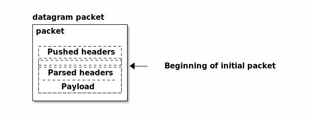

Datagram

A datagram can be used in two modes of operation, called “immediate commit” and “delayed commit”. In immediate commit mode, the `push` and `pop` methods immediately modify the underlying packet. However, this can be undesireable.

Even though the manipulations are relatively fast by using SIMD instructions to move and copy data when possible, performance-aware applications usually try to avoid as much of them as possible. This creates a conflict if the caller performs operations to push or parse a sequence of protocol headers in immediate commit mode.

This problem can be avoided by using delayed commit mode. In this mode, the `push` methods add the data to a separate buffer as intermediate storage. The buffer is prepended to the actual packet in a single operation by calling `datagram:commit`.

The `pop` methods are made light-weight in delayed commit mode as well by keeping track of an additional offset that indicates where the actual packet starts in the packet buffer. Each call to one of the `pop` methods simply increases the offset by the size of the popped piece of data. The accumulated actions will be applied as a single operation by `datagram:commit`.

The `push` and `pop` methods can be freely mixed in delayed commit mode.

Due to the destructive nature of these methods in immediate commit mode, they cannot be applied when the parse stack is not empty, because moving the data in the packet buffer will invalidate the parsed headers. The `push` and `pop` methods will raise an error in that case.

The buffer used in delayed commit mode has a fixed size of 512 bytes. This limits the size of data that can be pushed in a single operation. A sequence of push/commit operations can be used to push an arbitrary amount of data in chunks of up to 512 bytes.

— Method **datagram:new** *packet*, *protocol*, *options*

Creates a datagram for *packet* or from scratch if *packet* is `nil`. *Protocol* will be used by `parse_match` to parse the packet payload. If *protocol* is not `nil` it is set as the initial upper layer protocol. If *options* is not `nil` it must be a table that selects configurable properties of the class. Currently, the only option is the selection of immediate or delayed commit mode by setting the key `delayed_commit` to `false` or `true`, respectively. The default is immediate commit mode.

— Method **datagram:push** *header*

Prepends *header* to the front of the datagram. This method destructively modifies the underlying packet in immediate commit mode and raises an error if the parse stack is not empty.

In delayed commit mode, *header* is prepended to an intermediate buffer.

— Method **datagram:push_raw** *data*, *length*

This method behaves like the *datagram:push* method for an arbitrary chunk of memory of length *length* located at the address pointed to by *data*.

— Method **datagram:parse_match** *protocol*, *check*

Attempts to parse the next header in the datagram, thereby removing it from the payload. Returns a header instance of class *protocol* on success. If *protocol* is `nil` the current upper layer protocol as set by `datagram:new` or previous calls to `parse_match` is used.

If neither *protocol* nor the upper layer protocol is set or the constructor of the protocol class returns `nil`, the parsing operation has failed and `parse_match` returns `nil`. The datagram remains unchanged.

If the protocol class instance has been created successfully, it is passed as single argument to the anonymous function *check*.

If *check* returns a false value, the parsing has failed and `parse_match` returns `nil`. The packet remains unchanged.

If *check* is not supplied or if it returned a true value, the parsing has succeeded and the current upper layer protocol of the datagram is set to the value returned by `header:upper_layer`.

— Method **datagram:parse** *protocols_and_checks*

A wrapper around `parse_match` that allows parsing of a sequence of headers with a single method call.

If *protocols_and_checks* is a sequence of protocol class and check function pairs, `parse_match` is called for each pair. Returns the header object of the last header parsed or `nil` if any of the calls to `parse_match` return `nil`.

If called with a `nil` argument, this method is equivalent to `parse_match` called without arguments.

— Method **datagram:parse_n** *n*

A wrapper around `parse_match` that parses the next *n* protocol headers using the current upper layer protocol and subsequent values of `header:upper_layer`. It returns the last header object or `nil` if less than *n* headers could be parsed successfully.

— Method **datagram:unparse** *n*

Undoes the last *n* calls to `parse_match` on the datagram. E.g. prepends *n* parsed headers back to the payload. The sequence of parsed headers can be obtained by calling `stack`.

— Method **datagram:pop** *n*

Removes the leading *n* parsed headers from the datagram. Note that headers added via `push` can not be removed using `pop`. The caller has to ensure that the datagram contains at least *n* headers that were parsed using `parse_match`. The sequence of parsed headers can be obtained by calling `stack`. This method destructively modifies the underlying packet in immediate commit mode and raises an error if the parse stack is not empty.

In delayed commit mode, the packet is not modified and the parse stack remains valid.

For instance let *d* be an datagram with an Ethernet header followed by an IPv6 header. Assuming we have parsed both headers using `d:parse_n(2)`, we could call `d:pop(1)` to decapsulate the IPv6 packet from its Ethernet header.

— Method **datagram:pop_raw** *length*, *ulp*

Removes *length* bytes from the beginning of the datagram. If *ulp* is given it is set as the current upper layer protocol. This method destructively modifies the underlying packet in immediate commit mode and raises an error if the parse stack is not empty.

In delayed commit mode, the packet is not modified and the parse stack remains valid.

— Method **datagram:stack**

Returns the parsed header objects as a sequence.

— Method **datagram:packet**

Returns a packet (see `core.packet`) containing the datagram (including pushed headers).

— Method **datagram:payload** *pointer*, *length*

Combined payload accessor and setter method. Returns a pointer to the datagram payload and its byte size.

If *pointer* and *length* are supplied then *length* bytes starting from *pointer* are appended to the datagram’s payload.

— Method **datagram:data**

Returns `data` and `length` of the underlying packet.

- Method **datagram:commit**

If called in delayed commit mode, the operations accumulated by the `push` and `pop` methods since the creation of the datagram or the last invocation of *datagram:commit* are commited to the underlying packet. An error is raised if the parse stack is not empty.

The method can be safely called in immediate commit mode.

## IPsec

### Encapsulating Security Payload (lib.ipsec.esp)

The `lib.ipsec.esp` module contains two classes `encrypt` and `decrypt` which implement packet encryption and decryption with IPsec ESP in both tunnel and transport modes. Currently, the only supported cipher is AES-GCM cipher with 128‑bit keys, 4 bytes of salt, and a 12 byte authentication code. These classes do not implement any key exchange protocol.

References:

- [IPsec Wikipedia page](https://en.wikipedia.org/wiki/IPsec).
- [RFC 4303](https://tools.ietf.org/html/rfc4303) on IPsec ESP.
- [RFC 4106](https://tools.ietf.org/html/rfc4106) on using AES-GCM with IPsec ESP.
- [LISP Data-Plane Confidentiality](https://tools.ietf.org/html/draft-ietf-lisp-crypto-02) example of a software layer above these apps that includes key exchange.

— Method **encrypt:new** *config*

— Method **decrypt:new** *config*

Returns a new encryption/decryption context respectively. *Config* must a be a table with the following keys:

- `mode` - Encryption mode (string). The only accepted value is `"aes-gcm-128-12"`.
- `spi` - A 32 bit integer denoting the “Security Parameters Index” as specified in RFC 4303.
- `key` - Hexadecimal string of 32 digits (two digits for each byte, most significant digit first) that denotes 16 bytes of high-entropy key material as specified in RFC 4106.
- `salt` - Hexadecimal string of eight digits (two digits for each byte) that denotes four bytes of salt as specified in RFC 4106.
- `window_size` - *Optional*. Minimum width of the window in which out of order packets are accepted as specified in RFC 4303. The default is 128. (`decrypt` only.)
- `resync_threshold` - *Optional*. Number of consecutive packets allowed to fail decapsulation before attempting “Re-synchronization” as specified in RFC 4303. The default is 1024. (`decrypt` only.)
- `resync_attempts` - *Optional*. Number of attempts to re-synchronize a packet that triggered “Re-synchronization” as specified in RFC 4303. The default is 8. (`decrypt` only.)
- `auditing` - *Optional.* A boolean value indicating whether to enable or disable “Auditing” as specified in RFC 4303. The default is `nil` (no auditing). (`decrypt` only.)

#### Tunnel mode

In tunnel mode, encapsulation accepts packets of any format and wraps them in an ESP frame, encrypting the original packet contents. Decapsulation reverses the process: it removes the ESP frame and returns the original input packet.

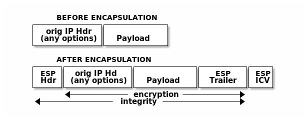

ESP-Tunnel

— Method **encrypt:encapsulate_tunnel** *packet*, *next_header*

Encapsulates *packet* and encrypts its payload. The ESP header’s *Next Header* field is set to *next_header*. Takes ownership of *packet* and returns a new packet.

Decapsulates *packet* and decrypts its payload. On success, takes ownership of *packet* and returns a new packet and the value of the ESP header’s *Next Header* field. Otherwise returns `nil`.

#### Transport mode

In transport mode, encapsulation accepts IPv6 packets and inserts a new ESP header between the outer IPv6 header and the inner protocol header (e.g. TCP, UDP, L2TPv3) and also encrypts the contents of the inner protocol header. Decapsulation does the reverse: it decrypts the inner protocol header and removes the ESP protocol header. In this mode it is expected that an Ethernet header precedes the outer IPv6 header.

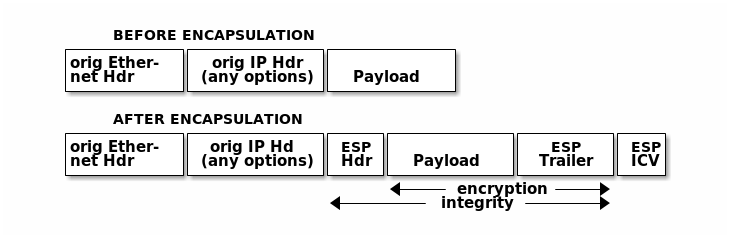

ESP-Transport

— Method **encrypt:encapsulate_transport6** *packet*

Encapsulates *packet* and encrypts its payload. On success, takes ownership of *packet* and returns a new packet. Otherwise returns `nil`.

— Method **decrypt:decapsulate_transport6** *packet*

Decapsulates *packet* and decrypts its payload. On success, takes ownership of *packet* and returns a new packet. Otherwise returns `nil`.

## Snabb NFV

### NFV config (program.snabbnfv.nfvconfig)

The `program.snabbnfv.nfvconfig` module implements a [Network Functions Virtualization](https://en.wikipedia.org/wiki/Network_Functions_Virtualization) component based on Snabb. It introduces a simple configuration file format to describe NFV configurations which it then compiles to app networks. This NFV component is compatible with [OpenStack Neutron](https://wiki.openstack.org/wiki/Neutron).

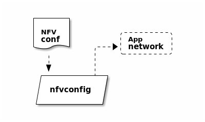

NFV

— Function **nfvconfig.load** *file*, *pci_address*, *socket_path*

Loads the NFV configuration from *file* and compiles an app network using *pci_address* and *socket_path* for the underlying NIC driver and `VhostUser` apps. Returns the resulting engine configuration.

#### NFV Configuration Format

The configuration file format understood by `program.snabbnfv.nfvconfig` is based on *Lua expressions*. Initially, it contains a list of NFV *ports*:

```
return { <port-1>, ..., <port-n> }
```

Each port is defined by a range of properties which correspond to the configuration parameters of the underlying apps (NIC driver, `VhostUser`, `PcapFilter`, `RateLimiter`, `nd_light` and `SimpleKeyedTunnel`):

```
port := { port_id        = <id>,          -- A unique string
          mac_address    = <mac-address>, -- MAC address as a string
          vlan           = <vlan-id>,     -- ..
          ingress_filter = <filter>,       -- A pcap-filter(7) expression
          egress_filter  = <filter>,       -- ..
          tunnel         = <tunnel-conf>,
          crypto         = <crypto-conf>,
          rx_police      = <n>,           -- Allowed input rate in Gbps
          tx_police      = <n> }          -- Allowed output rate in Gbps
```

The `tunnel` section deviates a little from `SimpleKeyedTunnel`’s terminology:

```
tunnel := { type          = "L2TPv3",     -- The only type (for now)
            local_cookie  = <cookie>,     -- As for SimpleKeyedTunnel
            remote_cookie = <cookie>,     -- ..
            next_hop      = <ip-address>, -- Gateway IP
            local_ip      = <ip-address>, -- ~ `local_address'
            remote_ip     = <ip-address>, -- ~ `remote_address'
            session       = <32bit-int> } -- ~ `session_id'
```

The `crypto` section allows configuration of traffic encryption based on `apps.ipsec.esp`:

```
crypto := { type          = "esp-aes-128-gcm", -- The only type (for now)
            spi           = <spi>,             -- As for AES128gcm
            transmit_key  = <key>,
            transmit_salt = <salt>,
            receive_key   = <key>,
            receive_salt  = <salt>,
            auditing      = <boolean> }
```

### snabbnfv traffic

The `snabbnfv traffic` program loads and runs a NFV configuration using `program.snabbnfv.nfvconfig`. It can be invoked like so:

```
./snabb snabbnfv traffic <file> <pci-address> <socket-path>
```

`snabbnfv traffic` runs the loaded configuration indefinitely and automatically reloads the configuration file if it changes (at most once every second).

### snabbnfv neutron2snabb

The `snabbnfv neutron2snabb` program converts Neutron database CSV dumps to the format used by `program.snabbnfv.nfvconfig`. For more info see Snabb NFV Architecture. It can be invoked like so:

```
./snabb snabbnfv neutron2snabb <csv-directory> <output-directory> [<hostname>]
```

`snabbnfv neutron2snabb` reads the Neutron configuration *csv-directory* and translates them to one `lib.nfv.conig` configuration file per physical network. If *hostname* is given, it overrides the hostname provided by `hostname(1)`.

## Watchdog (lib.watchdog.watchdog)

The `lib.watchdog.watchdog` module implements a per-thread watchdog functionality. Its purpose is to watch and kill processes which fail to call the watchdog periodically (e.g. hang).

It does so by using *alarm(3)* and *ualarm(3)* to have the OS send a *SIGALRM* to the process after a specified timeout. Because the process does not handle the signal it will be killed and exit with status *142*.

— Function **watchdog.set** *milliseconds*

Set watchdog timeout to *milliseconds*. Values for *milliseconds* greater than 1,000 are truncated to the next second. For example:

```
watchdog.set(1100) == watchdog.set(2000)
```

— Function **watchdog.reset**

Starts the timout if the watchdog has not yet been started and resets the timeout otherwise. If the timeout is reached the process will be killed.

— Function **watchdog.stop**

Disables the timeout.

# Snabblab

Servers devoted to the Snabb project and usable by all known developers.

Want to be a known developer? Sure! Just edit the [user account list](https://github.com/snabblab/snabblab-nixos/blob/master/modules/users.nix) with your user and send a pull request. No fuss.

## Guidelines

- Feel at home. These servers are here for you to play with and enjoy.
- Please run Snabb processes like this: `sudo lock ./snabb ...`. The `lock` command will automatically wait if somebody else is running a Snabb process on the same machine and that helps us avoid conflicts for access to hardware resources.
- Tell `luke@snabb.co` your email address(es) to get an invitation to the [Lab Slack](http://snabb.slack.com/).
- Don’t keep precious data on the servers. We might want to reinstall them at short notice.

## Servers

| Name | Purpose | SSH | Xeon model | NICs |
| --- | --- | --- | --- | --- |
| lugano-1 | General use | lugano-1.snabb.co | E3 1650v3 | 2 x 10G (82599), 4 x 10G (X710), 2 x 40G (XL710) |
| lugano-2 | General use | lugano-2.snabb.co | E3 1650v3 | 2 x 10G (82599), 4 x 10G (X710), 2 x 40G (XL710) |
| lugano-3 | General use | lugano-3.snabb.co | E3 1650v3 | 2 x 10G (82599), 2 x 100G (ConnectX-4) |
| lugano-4 | General use | lugano-4.snabb.co | E3 1650v3 | 2 x 10G (82599), 2 x 100G (ConnectX-4) |
| davos | Continuous Integration tests & driver development | lab1.snabb.co port 2000 | 2x E5 2603 | Diverse 10G/40G: Intel, SolarFlare, Mellanox, Chelsio, Broadcom. Installed upon request. |
| grindelwald | Snabb NFV testing | lab1.snabb.co port 2010 | 2x E5 2697v2 | 12 x 10G (Intel 82599) |
| interlaken | Haswell/AVX2 testing | lab1.snabb.co port 2030 | 2x E5 2620v3 | 12 x 10G (Intel 82599) |

## Get started

You are welcome to play, test, and develop on the `lugano-1` .. `lugano-4` servers. Once your account is added you can connect like this:

```
$ ssh user@lugano-1.snabb.co
```

and check the PCI devices and their addresses with `lspci`.

Certain cards (82599 and ConnectX-4) are cabled to themselves. That is, dual-port cards have their ports connected to each other. Certain other cards (X710/XL710) are currently not cabled. If you have special cabling needs then please open an issue on the snabblab-nixos.

## Using the lab

All servers run the latest stable version of [NixOS Linux distribution](http://nixos.org/nixos/about.html).

To quickly install a package:

```
$ nox <search string>
```

For other operations such as uninstalling a package, refer to `man nix-env`.

## Questions

If you have any questions or trouble, ask on [the #lab channel](https://snabb.slack.com/messages/lab/) or [open an issue](https://github.com/snabblab/snabblab-nixos).

## Thanks

We are grateful to [Silicom](http://www.silicom-usa.com/) for their sponsorship in the form of discounted network cards for `chur` and to [Netgate](http://www.netgate.com/) for giving us `jura`. Thanks gang!